# R for Data Science

## 2.3 arrange()

결측치는 항상 정렬 시 끝에 위치한다.

## 2.4 select()

`select(flights, year, month, day)` `select(flights, year:day)` `select(flights, -(year:day))`

helper 함수

- `starts_with("abc")` : “abc”로 시작하는 이름에 매칭
- `ends_with("xyz")` : “xyz”로 끝나는 이름에 매칭
- `contains("ijk")` : “ijk”를 포함하는 이름에 매칭
- `matches("(.)\\1")` : 반복되는 문자를 포함하는 어떤 변수에 매칭
- `num_range("x", 1:3)` : x1, x2, x3에 매칭

```r
df <- data_frame(x1 = 1:2, x2 = 1:2, x3 = 3:4, aa = 4:5, uxyz = 2:3, abcd = c(1, 5))
select(df, num_range("x", 1:3), matches("(.)\\1"), ends_with("xyz"))
```

```
## # A tibble: 2 x 5
##      x1    x2    x3    aa  uxyz
##   <int> <int> <int> <int> <int>
## 1     1     1     3     4     2
## 2     2     2     4     5     3
```

```r
rename(flights, tail_num = tailnum)
```

```
## # A tibble: 336,776 x 19
##     year month   day dep_time sched_dep_time dep_delay arr_time
##    <int> <int> <int>    <int>          <int>     <dbl>    <int>
##  1  2013     1     1      517            515         2      830
##  2  2013     1     1      533            529         4      850
##  3  2013     1     1      542            540         2      923
##  4  2013     1     1      544            545        -1     1004
##  5  2013     1     1      554            600        -6      812
##  6  2013     1     1      554            558        -4      740
##  7  2013     1     1      555            600        -5      913
##  8  2013     1     1      557            600        -3      709
##  9  2013     1     1      557            600        -3      838
## 10  2013     1     1      558            600        -2      753
## # ... with 336,766 more rows, and 12 more variables: sched_arr_time <int>,
## #   arr_delay <dbl>, carrier <chr>, flight <int>, tail_num <chr>,
## #   origin <chr>, dest <chr>, air_time <dbl>, distance <dbl>, hour <dbl>,
## #   minute <dbl>, time_hour <dttm>
```

`everything()` 옵션을 사용하면 변수를 데이터 프레임의 시작 위치로 옮길 때 유용하다.

```r
select(flights, time_hour, air_time, everything())
```

```
## # A tibble: 336,776 x 19
##    time_hour           air_time  year month   day dep_time sched_dep_time
##    <dttm>                 <dbl> <int> <int> <int>    <int>          <int>
##  1 2013-01-01 05:00:00      227  2013     1     1      517            515
##  2 2013-01-01 05:00:00      227  2013     1     1      533            529
##  3 2013-01-01 05:00:00      160  2013     1     1      542            540
##  4 2013-01-01 05:00:00      183  2013     1     1      544            545
##  5 2013-01-01 06:00:00      116  2013     1     1      554            600
##  6 2013-01-01 05:00:00      150  2013     1     1      554            558
##  7 2013-01-01 06:00:00      158  2013     1     1      555            600
##  8 2013-01-01 06:00:00       53  2013     1     1      557            600
##  9 2013-01-01 06:00:00      140  2013     1     1      557            600
## 10 2013-01-01 06:00:00      138  2013     1     1      558            600
## # ... with 336,766 more rows, and 12 more variables: dep_delay <dbl>,
## #   arr_time <int>, sched_arr_time <int>, arr_delay <dbl>, carrier <chr>,
## #   flight <int>, tailnum <chr>, origin <chr>, dest <chr>, distance <dbl>,
## #   hour <dbl>, minute <dbl>
```

`select()`는 중복된 변수를 입력하면 무시한다.

`one_of()`는 변수의 이름이 " “로 되어 있을 때 사용

```r
vars <- c(
  "year", "month", "day", "dep_delay", "arr_delay"
)
select(flights, one_of(vars))
```

```
## # A tibble: 336,776 x 5
##     year month   day dep_delay arr_delay
##    <int> <int> <int>     <dbl>     <dbl>
##  1  2013     1     1         2        11
##  2  2013     1     1         4        20
##  3  2013     1     1         2        33
##  4  2013     1     1        -1       -18
##  5  2013     1     1        -6       -25
##  6  2013     1     1        -4        12
##  7  2013     1     1        -5        19
##  8  2013     1     1        -3       -14
##  9  2013     1     1        -3        -8
## 10  2013     1     1        -2         8
## # ... with 336,766 more rows
```

```r
select(flights, contains("TIME", ignore.case = FALSE))
```

```
## # A tibble: 336,776 x 0
```

## 2.5 mutate()

새로운 변수만 활용하고 싶다면 `transmute()`

- 산술 연산자 :`+, -, *, /, ^`
- 나머지 연산자 : `%/% %%`
- log : `log(), log2(), log10()`
- Offets : `lead() lag()`
- Cumulative and rolling aggregates : `cumsum(), cunprod(), cummin(), cummax(), cummean()`
- 논리 연산자 : `<. <=, >, >=, !, =`
- 순위 : `min_rank(), row_number(), dense_rank(), percent_rank(), cume_dist()`

## 2.6 Exercisese

1. Currently dep_time and sched_dep_time are convenient to look at, but hard to compute with because they’re not really continuous numbers. Convert them to a more convenient representation of number of minutes since midnight.

517이면 5시 17분이라는 뜻인데 517그대로를 계산에 사용할 수는 없다. 따라서 분 단위로 바꾸겠다.

```r
mutate(flights, sched_dep_time = (sched_dep_time %/% 100) * 60 + sched_dep_time %% 100,
       dep_time = (dep_time %/% 100) * 60 + dep_time %% 100)
```

```
## # A tibble: 336,776 x 19
##     year month   day dep_time sched_dep_time dep_delay arr_time
##    <int> <int> <int>    <dbl>          <dbl>     <dbl>    <int>
##  1  2013     1     1      317            315         2      830
##  2  2013     1     1      333            329         4      850
##  3  2013     1     1      342            340         2      923
##  4  2013     1     1      344            345        -1     1004
##  5  2013     1     1      354            360        -6      812
##  6  2013     1     1      354            358        -4      740
##  7  2013     1     1      355            360        -5      913
##  8  2013     1     1      357            360        -3      709
##  9  2013     1     1      357            360        -3      838
## 10  2013     1     1      358            360        -2      753
## # ... with 336,766 more rows, and 12 more variables: sched_arr_time <int>,
## #   arr_delay <dbl>, carrier <chr>, flight <int>, tailnum <chr>,
## #   origin <chr>, dest <chr>, air_time <dbl>, distance <dbl>, hour <dbl>,
## #   minute <dbl>, time_hour <dttm>
```

2. Compare air_time with arr_time - dep_time. What do you expect to see? What do you see? What do you need to do to fix it?

1번에서 살펴 봤듯이 계산을 하면 안된다. 1번과 같이 변환한 후 계산을 해야한다. 하지만 arrtime - deptime을 했을 때 또 하나의 문제가 생긴다. 이전날에 출발해서 다음날에 도착하는 비행기는 음수값이 엄청 커져버린다.

22시에 출발한 비행기가 다음 날 1시에 도착했다고 하면 시간 차이는 3시간이 되어야 하지만 -21시간이 되어 버린다. 그래서 도착 시간에 24시간을 더한 다음 빼면 해결이 된다. 하지만 같은 날 9시와 12시라면 36 - 9 = 27시간이 되어 버리는데 이건 24시간으로 나머지 연산을 해버리면 해결이 된다.

```r
flights %>%
  mutate(dep_time = (dep_time %/% 100) * 60 + (dep_time %% 100),
         sched_dep_time = (sched_dep_time %/% 100) * 60 + (sched_dep_time %% 100),
         arr_time = (arr_time %/% 100) * 60 + (arr_time %% 100),
         sched_arr_time = (sched_arr_time %/% 100) * 60 + (sched_arr_time %% 100)) %>%
  transmute(diff = (arr_time + 60*24 - dep_time ) %% (60*24) - air_time) %>%
  arrange(diff)
```

```
## # A tibble: 336,776 x 1
##     diff
##    <dbl>
##  1  -345
##  2  -345
##  3  -345
##  4  -345
##  5  -344
##  6  -344
##  7  -344
##  8  -344
##  9  -344
## 10  -343
## # ... with 336,766 more rows
```

air_time이 어떻게 측정되는지 조사할 필요가 있을 것 같다.

3. Compare dep_time, sched_dep_time, and dep_delay. How would you expect those three numbers to be related?

dep_delay + sched_dep_time == dep_time가 되면 좋겠다.

하지만 이전 문제와 마찬가지로 전날 23시30분 예정된 비행기가 40분 지연되면 0시 10분에 출발하므로 두 시각을 더하면 23시 40분이 되어 버린다. 따라서 이전 문제와 같은 방식을 사용하면 해결이 가능하다.

```r
flights %>%
  mutate(
    dep_time = dep_time%/%100 * 60 + dep_time %% 100,
    sched_dep_time = sched_dep_time%/%100 * 60 + sched_dep_time%%100) %>%
  transmute(diff = (dep_time + 60 * 24 - dep_delay) %% (60 * 24) - sched_dep_time) %>%  # tolerance : 허용 오차
filter(diff != 0)
```

```
## # A tibble: 0 x 1
## # ... with 1 variable: diff <dbl>
```

정확하게 일치함을 알 수 있다.

4. Find the 10 most delayed flights using a ranking function. How do you want to handle ties? Carefully read the documentation for min_rank().

```r
flights %>%
  arrange(desc(dep_delay)) %>%
  head(10)
```

```
## # A tibble: 10 x 19
##     year month   day dep_time sched_dep_time dep_delay arr_time
##    <int> <int> <int>    <int>          <int>     <dbl>    <int>
##  1  2013     1     9      641            900      1301     1242
##  2  2013     6    15     1432           1935      1137     1607
##  3  2013     1    10     1121           1635      1126     1239
##  4  2013     9    20     1139           1845      1014     1457
##  5  2013     7    22      845           1600      1005     1044
##  6  2013     4    10     1100           1900       960     1342
##  7  2013     3    17     2321            810       911      135
##  8  2013     6    27      959           1900       899     1236
##  9  2013     7    22     2257            759       898      121
## 10  2013    12     5      756           1700       896     1058
## # ... with 12 more variables: sched_arr_time <int>, arr_delay <dbl>,
## #   carrier <chr>, flight <int>, tailnum <chr>, origin <chr>, dest <chr>,
## #   air_time <dbl>, distance <dbl>, hour <dbl>, minute <dbl>,
## #   time_hour <dttm>
```

또는

```r
filter(flights, min_rank(desc(dep_delay)) <= 10)
```

```
## # A tibble: 10 x 19
##     year month   day dep_time sched_dep_time dep_delay arr_time
##    <int> <int> <int>    <int>          <int>     <dbl>    <int>
##  1  2013     1     9      641            900      1301     1242
##  2  2013     1    10     1121           1635      1126     1239
##  3  2013    12     5      756           1700       896     1058
##  4  2013     3    17     2321            810       911      135
##  5  2013     4    10     1100           1900       960     1342
##  6  2013     6    15     1432           1935      1137     1607
##  7  2013     6    27      959           1900       899     1236
##  8  2013     7    22      845           1600      1005     1044
##  9  2013     7    22     2257            759       898      121
## 10  2013     9    20     1139           1845      1014     1457
## # ... with 12 more variables: sched_arr_time <int>, arr_delay <dbl>,
## #   carrier <chr>, flight <int>, tailnum <chr>, origin <chr>, dest <chr>,
## #   air_time <dbl>, distance <dbl>, hour <dbl>, minute <dbl>,
## #   time_hour <dttm>
```

```r
# flights %>% top_n(n = 10, wt = dep_delay)
```

min_rank와 arrange의 차이는 min_rank가 1~10위를 원본 데이터 순서대로 보여주지만 arrange는 1~10위를 정렬해서 보여준다.

min_rank, arrange, head

*min_rank()*

```r
a <- c(1,2,3,3,NA, 5,6)
min_rank(a) # rank(a, ties.method = "min")와 동일
```

```
## [1]  1  2  3  3 NA  5  6
```

```r
# 여기서 tie는 같은 거리에 있는 데이터를 말함

row_number(a)
```

```
## [1]  1  2  3  4 NA  5  6
```

```r
# rank(a, ties.method = "max")
iris %>%
  group_by(Species) %>%
  mutate(id = row_number()) %>%
  select(id) %>%
  tail()
```

```
## # A tibble: 6 x 2
## # Groups:   Species [1]
##   Species      id
##   <fct>     <int>
## 1 virginica    45
## 2 virginica    46
## 3 virginica    47
## 4 virginica    48
## 5 virginica    49
## 6 virginica    50
```

이런식으로 행 번호를 매길 수 있다.

```r
percent_rank(a)
```

```
## [1] 0.0 0.2 0.4 0.4  NA 0.8 1.0
```

```r
cume_dist(a)
```

```
## [1] 0.1666667 0.3333333 0.6666667 0.6666667        NA 0.8333333 1.0000000
```

```r
dense_rank(a)
```

```
## [1]  1  2  3  3 NA  4  5
```

```r
ntile(a, 4)
```

```
## [1]  1  1  2  3 NA  3  4
```

## 2.7 summarize()

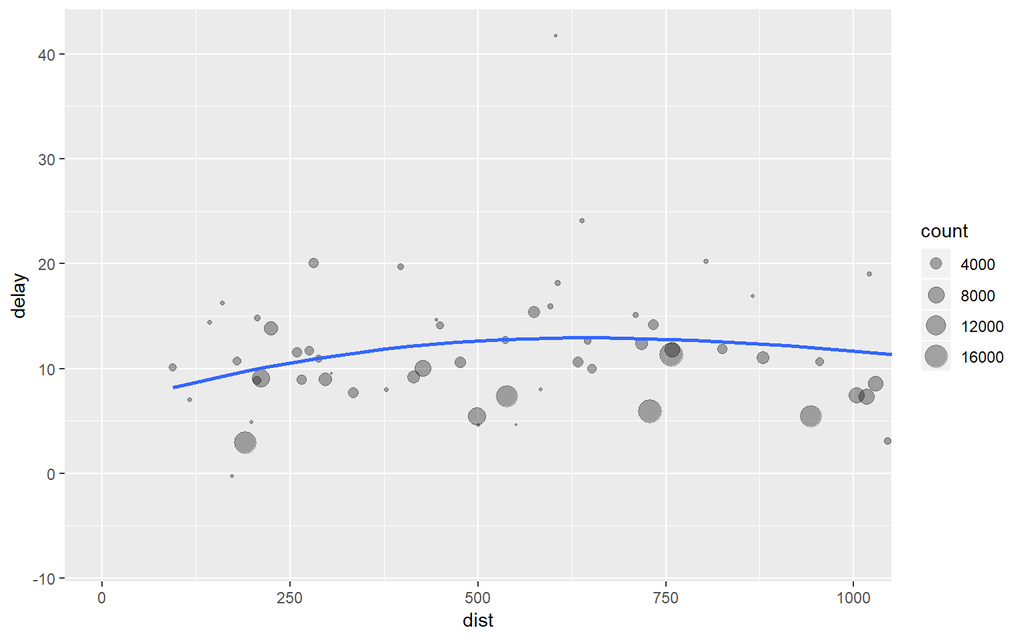

```r
delay <- flights %>%
  group_by(dest) %>%
  summarise(count = n(),
            dist = mean(distance, na.rm = TRUE),
            delay = mean(arr_delay, na.rm = TRUE)
            ) %>%
  filter(count > 20, dest != "HNL")
# Honolulu 공항은 가장 가까운 공항보다 2배나 멀다.

base <- ggplot(delay, aes(dist, delay)) +
  geom_point(aes(size = count), alpha = 1/3) +
  geom_smooth(se = FALSE) +
  scale_size_area()
base + coord_cartesian(xlim = c(0, 1000)) # delay가 거리 750까지 증가하고 그 이후 감소. xlim사용시 회귀선이 바뀐다.
```

> Counts

```r
not_cancelled <- flights %>%
  filter(!is.na(dep_delay), !is.na(arr_delay))
```

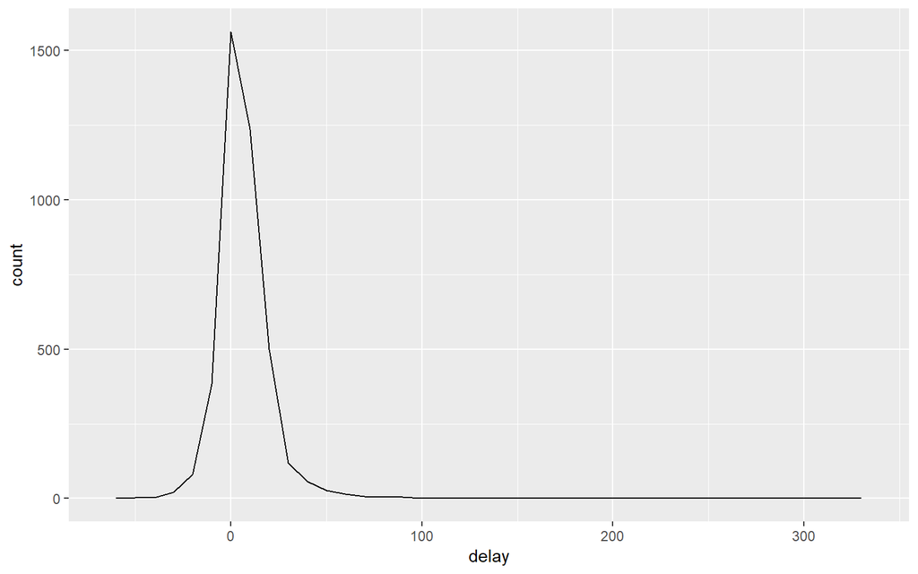

```r
delays <- not_cancelled %>%
  group_by(tailnum) %>%
  summarize(
    delay = mean(arr_delay)
  )
ggplot(data = delays, mapping = aes(x = delay)) +
  geom_freqpoly(binwidth = 10)
```

평균 delay가 5시간(300분)이 되는 비행기들도 있다.

다음처럼 관측치 수를 x축에 두고 관심있는 변수를 y축에 두는 플랏을 기억해두자.

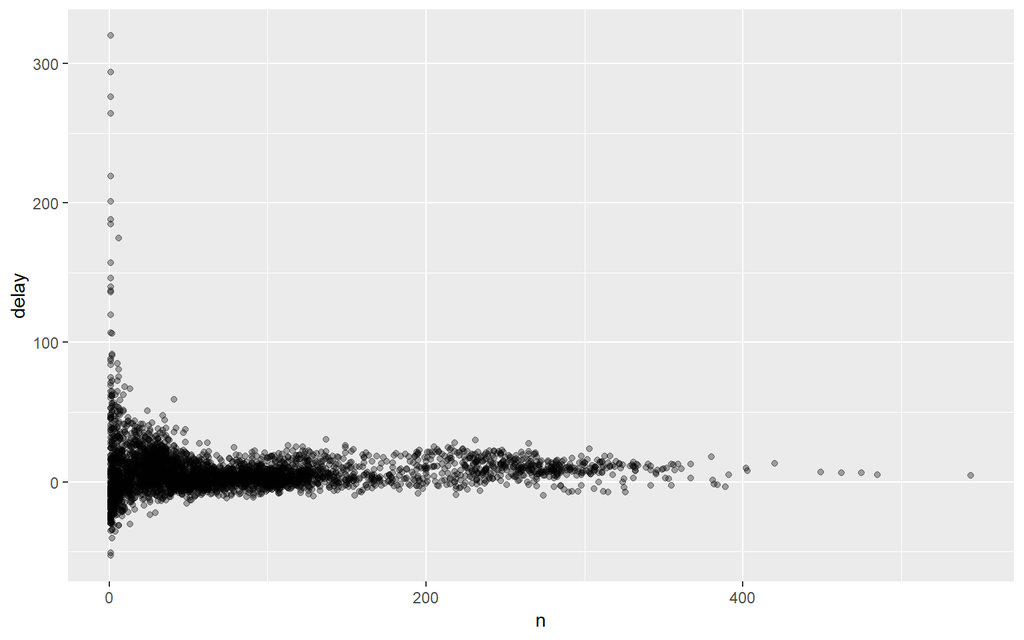

```r
delays <- not_cancelled %>%
  group_by(tailnum) %>%
  summarise(
    delay = mean(arr_delay, na.rm = TRUE),
    n = n()
  )

ggplot(delays, aes(n, delay)) +
  geom_point(alpha = 1/3)
```

그룹 크기와 평균에 대한 플랏을 그릴 때 마다 분산이 표본 크기에 비례해서 감소한다. 상식적으로 생각해도 비행 횟수가 적은 기체보다는 많은 기체가 분산이 적을 것이다.

이런 종류의 플랏을 볼 때 가장 작은 수의 관측치를 제거하는 것이 도움이 될 수 있다. 그러면 작은 그룹의 변동을 제거할 수 있다.

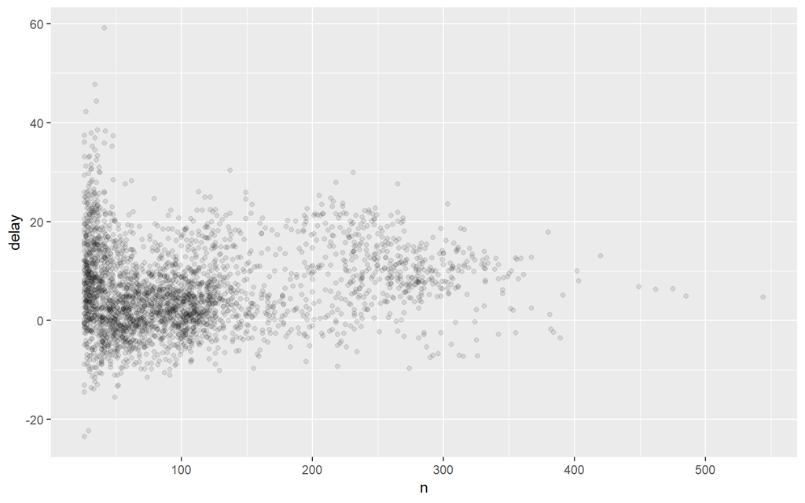

```r
delays %>%
  filter(n > 25) %>%
  ggplot(aes(n, delay)) +
    geom_point(alpha = 1/10)
```

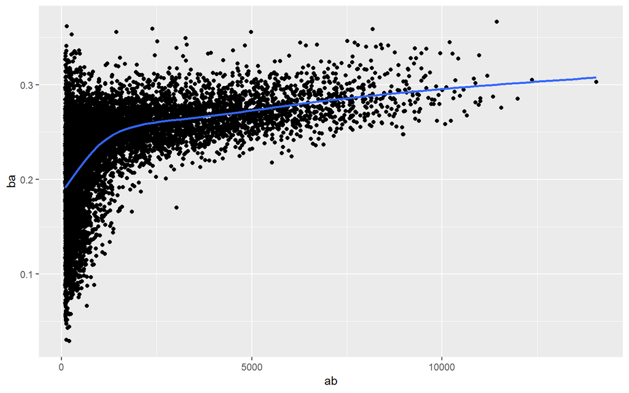

```r
# Convert to a tibble so it prints nicely
batting <- as_tibble(Lahman::Batting)
batters <- batting %>%
  group_by(playerID) %>%
  summarize(
    ba = sum(H, na.rm = TRUE) / sum(AB, na.rm = TRUE),
    ab = sum(AB, na.rm = TRUE)
  )
batters %>%
  filter(ab > 100) %>%
  ggplot(mapping = aes(x = ab, y = ba)) +
  geom_point() +
  geom_smooth(se = FALSE)
```

ab가 커질수록 분산이 작아지는 것은 아까 전에 살펴 봤듯이 당연하다. 양의 상관관계를 보이는데 이것은 팀은 베스트 플레이어를 선택하기 때문일 것이다.

다음 링크를 클릭해서 좀 더 공부해보자. 베이지안 수업 듣고 다시..

http://varianceexplained.org/r/empirical_bayes_baseball/ http://www.evanmiller.org/how-not-to-sort-by-average-rating.html

### 2.7.1 Useful Summary Functions

위치 척도 : `mean(x), median(x)`

논리 subsetting과 결합하면 유용하다.

```r
not_cancelled %>%
  group_by(year, month, day) %>%
  summarize(
    # average delay:
    avg_delay1 = mean(arr_delay),
    # average positive delay:
    avg_delay2 = mean(arr_delay[arr_delay > 0])
  )
```

```
## # A tibble: 365 x 5
## # Groups:   year, month [?]
##     year month   day avg_delay1 avg_delay2
##    <int> <int> <int>      <dbl>      <dbl>
##  1  2013     1     1     12.7         32.5
##  2  2013     1     2     12.7         32.0
##  3  2013     1     3      5.73        27.7
##  4  2013     1     4     -1.93        28.3
##  5  2013     1     5     -1.53        22.6
##  6  2013     1     6      4.24        24.4
##  7  2013     1     7     -4.95        27.8
##  8  2013     1     8     -3.23        20.8
##  9  2013     1     9     -0.264       25.6
## 10  2013     1    10     -5.90        27.3
## # ... with 355 more rows
```

분산 척도 : `sd(x), IQR(x), mad(x)`

Cf. median absolute deviation

http://eurekastatistics.com/using-the-median-absolute-deviation-to-find-outliers/

순위 척도 : `min(x), qunatile(x, 0.25), max(x)`

위치 척도 : `first(x), nth(x, 2), last(x), range(x)`

counts : `sum(!is.na(x)), n_distinct(x), count(tailnum, wt = distance)`를 사용하고, `mean(x)` 와 논리연산자의 결합은 비율을 알 수 있다.

### 2.7.2 Grouping by Multiple Variables

```r
daily <- flights %>% group_by(year, month, day)
(per_day <- summarise(daily, flights = n()))
```

```
## # A tibble: 365 x 4
## # Groups:   year, month [?]
##     year month   day flights
##    <int> <int> <int>   <int>
##  1  2013     1     1     842
##  2  2013     1     2     943
##  3  2013     1     3     914
##  4  2013     1     4     915
##  5  2013     1     5     720
##  6  2013     1     6     832
##  7  2013     1     7     933
##  8  2013     1     8     899
##  9  2013     1     9     902
## 10  2013     1    10     932
## # ... with 355 more rows
```

```r
(per_month <- summarise(per_day, flights = sum(flights)))
```

```
## # A tibble: 12 x 3
## # Groups:   year [?]
##     year month flights
##    <int> <int>   <int>
##  1  2013     1   27004
##  2  2013     2   24951
##  3  2013     3   28834
##  4  2013     4   28330
##  5  2013     5   28796
##  6  2013     6   28243
##  7  2013     7   29425
##  8  2013     8   29327
##  9  2013     9   27574
## 10  2013    10   28889
## 11  2013    11   27268
## 12  2013    12   28135
```

```r
(per_year <- summarise(per_month, flights = sum(flights)))
```

```
## # A tibble: 1 x 2
##    year flights
##   <int>   <int>
## 1  2013  336776
```

```r
daily %>%
  ungroup() %>%
  summarise(flights = n())
```

```
## # A tibble: 1 x 1
##   flights
##     <int>
## 1  336776
```

## 2.8 Exercises

1. Brainstorm at least five different ways to assess the typical delay characteristics of a group of flights. Consider the following scenarios:

많은 경우에, 도착 지연이 좀 더 중요하다. 도착이 늦는 것은 항공편이나 회의처럼 여행의 다음 단꼐에 혼란을 주기 때문이다. 도착시간에 영향 없이 출발 시간이 지연된다면 승객은 제시간에 도착하고 이 연착은 미래 계획과 여행 시간에 영향을 미치지 않는다.

도착시간의 변동은 일관성보다 나쁘다. 만약 항공편이 항상 30분 늦고 그런 연착을 안다면 마치 도착시간이 지연된 시간처럼 생각할 수 있다. 여행객은 쉽게 이것에 대해 계획을 짤 수 있다. 만약 항공편의 연착이 좀 더 다양하다면 계획을 짜기가 어려워진다.

• A flight is 15 minutes early 50% of the time, and 15 minutes late 50% of the time.

이게 무슨뜻이냐면 15분 늦은 비행기의 비율과 15분 일찍 온 비행기의 비율이 동일하다는 뜻이다. 즉, -15 ~ 15분의 연착시간은 없다.

우선 A flight이므로 항공편별로 찾아야 한다.

```r
flights %>%
  group_by(flight) %>%
  summarise(
    early_15_min = mean(arr_delay <= -15, na.rm = TRUE),
    late_15_min = mean(arr_delay >=15, na.rm = TRUE)) %>%
  filter(early_15_min == 0.5, late_15_min == 0.5)
```

```
## # A tibble: 21 x 3
##    flight early_15_min late_15_min
##     <int>        <dbl>       <dbl>
##  1    107          0.5         0.5
##  2   2072          0.5         0.5
##  3   2366          0.5         0.5
##  4   2500          0.5         0.5
##  5   2552          0.5         0.5
##  6   3495          0.5         0.5
##  7   3505          0.5         0.5
##  8   3518          0.5         0.5
##  9   3544          0.5         0.5
## 10   3651          0.5         0.5
## # ... with 11 more rows
```

21개의 항공편이 있다.

• A flight is always 10 minutes late.

항상 10분씩 늦는 항공편을 필터링하자.

```r
flights %>%
  group_by(flight) %>%
  summarise(late_10 = mean(arr_delay == 10, na.rm = TRUE)) %>%
  filter(late_10 == 1)
```

```
## # A tibble: 5 x 2
##   flight late_10
##    <int>   <dbl>
## 1   2254       1
## 2   3656       1
## 3   3785       1
## 4   3880       1
## 5   5854       1
```

• A flight is 30 minutes early 50% of the time, and 30 minutes late 50% of the time.

```r
flights %>%
  group_by(flight) %>%
  summarise(
    early_30_min = mean(arr_delay <= -30, na.rm = TRUE),
    late_30_min = mean(arr_delay >= 30, na.rm = TRUE)
  ) %>%
  filter(early_30_min == 0.5, late_30_min == 0.5)
```

```
## # A tibble: 3 x 3
##   flight early_30_min late_30_min
##    <int>        <dbl>       <dbl>
## 1   3651          0.5         0.5
## 2   3916          0.5         0.5
## 3   3951          0.5         0.5
```

3편 뿐이다.

• 99% of the time a flight is on time. 1% of the time it’s 2 hours late. Which is more important: arrival delay or departure delay?

```r
flights %>%
  group_by(flight) %>%
  summarise(
    on_time = mean(arr_delay == 0, na.rm = TRUE),
    late_time = mean(arr_delay == 120, na.rm = TRUE)
                    ) %>%
  filter(on_time == 0.99, late_time == 0.01)
```

```
## # A tibble: 0 x 3
## # ... with 3 variables: flight <int>, on_time <dbl>, late_time <dbl>
```

2. Come up with another approach that will give you the same output as not_cancelled %>% count(dest) and not_cancelled %>% count(tailnum, wt = distance) (without using count()).

```r
not_cancelled %>%
  group_by(dest) %>%
  summarise(n = n())
```

```
## # A tibble: 104 x 2
##    dest      n
##    <chr> <int>
##  1 ABQ     254
##  2 ACK     264
##  3 ALB     418
##  4 ANC       8
##  5 ATL   16837
##  6 AUS    2411
##  7 AVL     261
##  8 BDL     412
##  9 BGR     358
## 10 BHM     269
## # ... with 94 more rows
```

```r
not_cancelled %>%
  group_by(tailnum) %>%
  summarise(sum_dist = sum(distance, na.rm = TRUE))
```

```
## # A tibble: 4,037 x 2
##    tailnum sum_dist
##    <chr>      <dbl>
##  1 D942DN      3418
##  2 N0EGMQ    239143
##  3 N10156    109664
##  4 N102UW     25722
##  5 N103US     24619
##  6 N104UW     24616
##  7 N10575    139903
##  8 N105UW     23618
##  9 N107US     21677
## 10 N108UW     32070
## # ... with 4,027 more rows
```

`n()`또는 `count`는 weight를 sum(nrow(x))로 줬다고 생각하면 쉬울 듯 하다. count, weight 보다는 group_by, summarise(sum())이 직관적인듯.

3. Our definition of cancelled flights (is.na(dep_delay) | is.na(arr_delay)) is slightly suboptimal. Why? Which is the most important column?

출발해서 도착 하지 않을 수는 없으니까 `!is.na(dep_delay)`

4. Look at the number of cancelled flights per day. Is there a pattern? Is the proportion of cancelled flights related to the average delay?

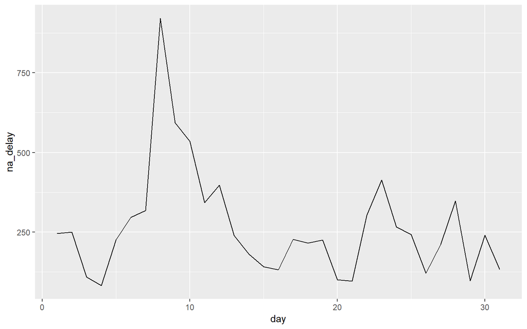

```r
cancel_day <- flights %>%
  group_by(day) %>%
  summarise(
    na_delay = sum(is.na(dep_delay))
    )
ggplot(cancel_day, aes(day, na_delay)) +
  geom_line()
```

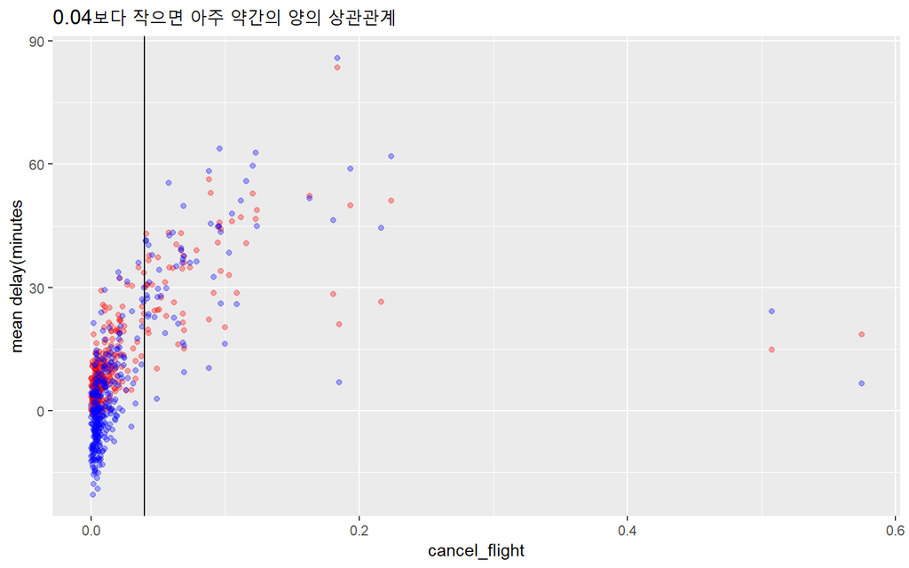

```r
flights %>% mutate(date = lubridate::make_date(year, month, day)) %>%
  group_by(date) %>%
  summarise(
    cancel_flight = sum(is.na(dep_time)) / n(),
    avg_dep_delay = mean(dep_delay, na.rm = TRUE),
    avg_arr_delay = mean(arr_delay, na.rm = TRUE)
            ) %>%
  ggplot(aes(cancel_flight)) +
    geom_point(aes(y = avg_dep_delay, colour = "dep"), colour = "red", alpha = 1/3) +
    geom_point(aes(y = avg_arr_delay, colour = "arr"), colour = "blue", alpha = 1/3) +
  ylab("mean delay(minutes") +
  geom_vline(aes(xintercept = 0.04)) +
  ggtitle("0.04보다 작으면 아주 약간의 양의 상관관계")
```

참고로 group_by(date)와 group_by(year, month, day)는 같은 결과다.

5. Which carrier has the worst delays? Challenge: can you disentangle the effects of bad airports versus bad carriers? Why/why not? (Hint: think about flights %>% group_by(carrier, dest) %>% summarize(n()).)

이건 나중에 제대로 풀어보자.

항공사중에서 나쁜 것, 항공편 중에서 나쁜 것은 단순히 평균과 표준편차를 이용하여 판단할 수 있을 것이다. 문제는 두개의 효과를 어떻게 풀어서 생각할 것인가?

```r
flights %>%
  group_by(carrier) %>%
  summarise(sd_delay = sd(arr_delay, na.rm = TRUE),
            avg_delay = mean(arr_delay, na.rm = TRUE),
            n = n()) %>%
  arrange(desc(sd_delay))
```

```
## # A tibble: 16 x 4
##    carrier sd_delay avg_delay     n
##    <chr>      <dbl>     <dbl> <int>
##  1 HA          75.1    -6.92    342
##  2 F9          61.6    21.9     685
##  3 FL          54.1    20.1    3260
##  4 YV          52.9    15.6     601
##  5 9E          50.1     7.38  18460
##  6 VX          50.0     1.76   5162
##  7 EV          49.9    15.8   54173
##  8 OO          48.6    11.9      32
##  9 WN          46.9     9.65  12275
## 10 DL          44.4     1.64  48110
## 11 MQ          43.2    10.8   26397
## 12 B6          42.8     9.46  54635
## 13 AA          42.5     0.364 32729
## 14 UA          41.0     3.56  58665
## 15 AS          36.5    -9.93    714
## 16 US          33.1     2.13  20536
```

n이 작으면 항공사가 작아서 그렇다고 쳐도 n이 큰데 delay가 크면 문제가 있어 보인다.

```r
flights %>%
  summarise(n_distinct(carrier),
            n_distinct(origin),
            n_distinct(dest))
```

```
## # A tibble: 1 x 3
##   `n_distinct(carrier)` `n_distinct(origin)` `n_distinct(dest)`
##                   <int>                <int>              <int>
## 1                    16                    3                105
```

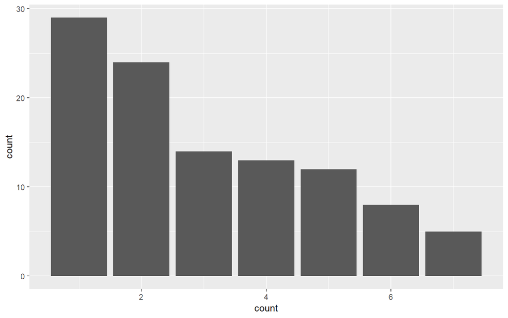

```r
flights %>%
  group_by(dest) %>%
  summarise(count = n_distinct(carrier, na.rm = TRUE)) %>%
  arrange(desc(count)) %>%
  ggplot(aes(count)) +
  geom_bar() # 목적지 별로 항공사가 한 두개 뿐인 곳이 많아 # 효과를 구분하기 어렵다
```

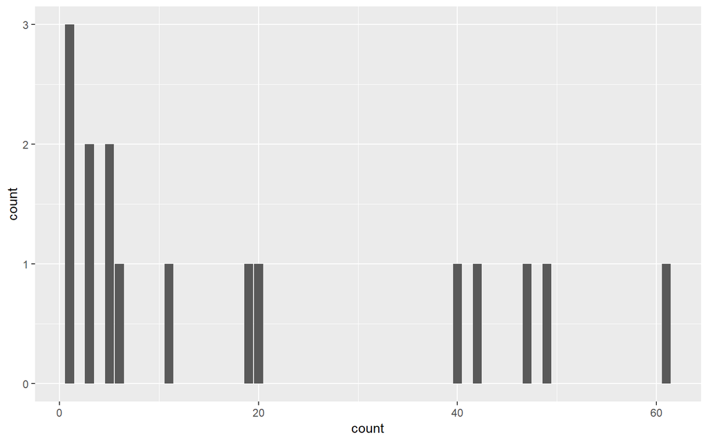

```r
flights %>%
  group_by(carrier) %>%
  summarise(count = n_distinct(dest, na.rm = TRUE)) %>%
  arrange(desc(count)) %>%
  ggplot(aes(count)) +
  geom_bar()
```

```r
library(magrittr)
flights %$%
  table(carrier, dest)
```

```
##        dest
## carrier   ABQ   ACK   ALB   ANC   ATL   AUS   AVL   BDL   BGR   BHM   BNA
##      9E     0     0     0     0    59     2    10     0     1     0   474
##      AA     0     0     0     0     0   365     0     0     0     0     0
##      AS     0     0     0     0     0     0     0     0     0     0     0
##      B6   254   265     0     0     0   747     0     0     0     0     0
##      DL     0     0     0     0 10571   357     0     0     0     0     1
##      EV     0     0   439     0  1764     0   265   435   374   297  2170
##      F9     0     0     0     0     0     0     0     0     0     0     0
##      FL     0     0     0     0  2337     0     0     0     0     0     0
##      HA     0     0     0     0     0     0     0     0     0     0     0
##      MQ     0     0     0     0  2322     0     0     0     0     0  2404
##      OO     0     0     0     0     0     0     0     0     0     0     0
##      UA     0     0     0     8   103   670     0     8     0     0     0
##      US     0     0     0     0     0     0     0     0     0     0     0
##      VX     0     0     0     0     0     0     0     0     0     0     0
##      WN     0     0     0     0    59   298     0     0     0     0  1284
##      YV     0     0     0     0     0     0     0     0     0     0     0
##        dest
## carrier   BOS   BQN   BTV   BUF   BUR   BWI   BZN   CAE   CAK   CHO   CHS
##      9E   914     0     2   833     0   856     0     3     0     0   348
##      AA  1455     0     0     0     0     0     0     0     0     0     0
##      AS     0     0     0     0     0     0     0     0     0     0     0
##      B6  4383   599  1364  2803   371     0     0     0     0     0   613
##      DL   972     0     0     3     0     0     0     0     0     0     0
##      EV   159     0  1223  1042     0   352     0   113     0    52  1922
##      F9     0     0     0     0     0     0     0     0     0     0     0
##      FL     0     0     0     0     0     0     0     0   864     0     0
##      HA     0     0     0     0     0     0     0     0     0     0     0
##      MQ     0     0     0     0     0   365     0     0     0     0     0
##      OO     0     0     0     0     0     0     0     0     0     0     0
##      UA  3342   297     0     0     0     0    36     0     0     0     1
##      US  4283     0     0     0     0     0     0     0     0     0     0
##      VX     0     0     0     0     0     0     0     0     0     0     0
##      WN     0     0     0     0     0   208     0     0     0     0     0
##      YV     0     0     0     0     0     0     0     0     0     0     0
##        dest
## carrier   CLE   CLT   CMH   CRW   CVG   DAY   DCA   DEN   DFW   DSM   DTW
##      9E   349   291    13     0  1559   391  1074     0   379    91  1013
##      AA     0     0     0     0     0     0     0     0  7257     0     0
```

[output cut: 125 more lines]

```
##      AA     0   311     0     0     0     0
##      AS     0     0     0     0     0     0
##      B6  1266  2800     0     0     0     0
##      DL     0  2129     0     0     0     0
##      EV   325     1   315    68   323   292
##      F9     0     0     0     0     0     0
##      FL     0     0     0     0     0     0
##      HA     0     0     0     0     0     0
##      MQ     0   254     0    33     0   744
##      OO     0     0     0     0     0     0
##      UA     0  1968     0     0     0     0
##      US     0     0     0     0     0     0
##      VX     0     0     0     0     0     0
##      WN     0     0     0     0     0     0
##      YV     0     0     0     0     0     0
```

상호작용이 없다면 두 효과를 분리 할 수 있다고 말할 수 있을 것 같다. 하지만 테이블에서 볼 수 있듯이, 0이 지나치게 많아서 판단은 불가능하다.(실험계획법 참고)

```r
flights %>%
  group_by(carrier, dest) %>%
  summarise(
    n = n(),
    mean_delay = mean(arr_delay, na.rm = TRUE)
    ) %>%
  group_by(carrier) %>%
  summarise(mad_delay = mad(mean_delay, na.rm = TRUE)) %>%
  arrange(desc(mad_delay))
```

```
## # A tibble: 16 x 2
##    carrier mad_delay
##    <chr>       <dbl>
##  1 VX          12.4
##  2 OO          10.5
##  3 YV           8.97
##  4 9E           8.20
##  5 EV           7.09
##  6 DL           7.00
##  7 UA           5.04
##  8 US           5.03
##  9 B6           5.00
## 10 WN           4.51
## 11 AA           3.31
## 12 MQ           2.88
## 13 FL           1.55
## 14 AS           0
## 15 F9           0
## 16 HA           0
```

평균 연착이 길수록, mad가 클수록 좋지 않은 항공사(carrier)이다. 주의할 점은 평균연착이 0이라고 해서 제시간에 온다는 것을 의미하는 것이 아니고 또한 mad가 0이라고 해서 제시간에 오는것도 아니다.

sd 대신 mad를 사용한 이유는 0, 1, 2 카운트가 너무 많다. 즉, 표본이 너무 적다.

6. For each plane, count the number of flights before the first delay of greater than 1 hour.

`cumany()`를 사용한다.

```r
flights %>%
    mutate(arr_date = lubridate::make_datetime(year, month, day)) %>%
    group_by(tailnum) %>%
    arrange(arr_date) %>%
    filter(!cumany(arr_delay > 60)) %>%
    summarise(n = n()) %>%
    arrange(desc(n))
```

```
## # A tibble: 3,748 x 2
##    tailnum     n
##    <chr>   <int>
##  1 N705TW     97
##  2 N765US     97
##  3 N12125     94
##  4 N320AA     94
##  5 N13110     91
##  6 N3763D     82
##  7 N58101     82
##  8 N17122     81
##  9 N961UW     80
## 10 N950UW     79
## # ... with 3,738 more rows
```

### 2.8.1 Grouped Mutates (and Filters)

- Find the worst members of each group :

```r
flights_sml <- select(flights,
                      year:day,
                      ends_with("delay"),
                      distance,
                      air_time
)
flights_sml %>%
  group_by(year, month, day) %>%
  filter(rank(desc(arr_delay)) < 10)
```

```
## # A tibble: 3,306 x 7
## # Groups:   year, month, day [365]
##     year month   day dep_delay arr_delay distance air_time
##    <int> <int> <int>     <dbl>     <dbl>    <dbl>    <dbl>
##  1  2013     1     1       853       851      184       41
##  2  2013     1     1       290       338     1134      213
##  3  2013     1     1       260       263      266       46
##  4  2013     1     1       157       174      213       60
##  5  2013     1     1       216       222      708      121
##  6  2013     1     1       255       250      589      115
##  7  2013     1     1       285       246     1085      146
##  8  2013     1     1       192       191      199       44
##  9  2013     1     1       379       456     1092      222
## 10  2013     1     2       224       207      550       94
## # ... with 3,296 more rows
```

- Find all groups bigger than a threshold :

```r
popular_dests <- flights %>%
  group_by(dest) %>%
  filter(n() > 365)
```

- Standardize to compute per group metrics :

```r
popular_dests %>%
  filter(arr_delay > 0) %>%
  mutate(prop_delay = arr_delay / sum(arr_delay)) %>%
  select(year:day, dest, arr_delay, prop_delay)
```

```
## # A tibble: 131,106 x 6
## # Groups:   dest [77]
##     year month   day dest  arr_delay prop_delay
##    <int> <int> <int> <chr>     <dbl>      <dbl>
##  1  2013     1     1 IAH          11  0.000111
##  2  2013     1     1 IAH          20  0.000201
##  3  2013     1     1 MIA          33  0.000235
##  4  2013     1     1 ORD          12  0.0000424
##  5  2013     1     1 FLL          19  0.0000938
##  6  2013     1     1 ORD           8  0.0000283
##  7  2013     1     1 LAX           7  0.0000344
##  8  2013     1     1 DFW          31  0.000282
##  9  2013     1     1 ATL          12  0.0000400
## 10  2013     1     1 DTW          16  0.000116
## # ... with 131,096 more rows
```

grouped mutates와 filters에서 자연스럽게 작동하는 함수들은 윈도우 함수로 알려져 있다. `vignette("window-functions")`를 보라.

## 2.9 Exercises

1. Which plane (tailnum) has the worst on-time record?

```r
flights %>%
  group_by(tailnum) %>%
  summarise(prop_on_time = sum(arr_delay <= 30 & !is.na(arr_delay))/n(),
            mean_arr_delay = mean(arr_delay, na.rm=TRUE),
            flights = n()) %>%
  arrange(prop_on_time, desc(mean_arr_delay))
```

```
## # A tibble: 4,044 x 4
##    tailnum prop_on_time mean_arr_delay flights
##    <chr>          <dbl>          <dbl>   <int>
##  1 N844MH             0            320       1
##  2 N911DA             0            294       1
##  3 N922EV             0            276       1
##  4 N587NW             0            264       1
##  5 N851NW             0            219       1
##  6 N928DN             0            201       1
##  7 N7715E             0            188       1
##  8 N654UA             0            185       1
##  9 N427SW             0            157       1
## 10 N136DL             0            146       1
## # ... with 4,034 more rows
```

```r
flights %>%
  group_by(tailnum) %>%
  filter(all(is.na(arr_delay))) %>%
    tally(sort=TRUE)
```

```
## # A tibble: 7 x 2
##   tailnum     n
##   <chr>   <int>
## 1 <NA>     2512
## 2 N347SW      1
## 3 N728SK      1
## 4 N768SK      1
## 5 N862DA      1
## 6 N865DA      1
## 7 N939DN      1
```

2. What time of day should you fly if you want to avoid delays as much as possible?

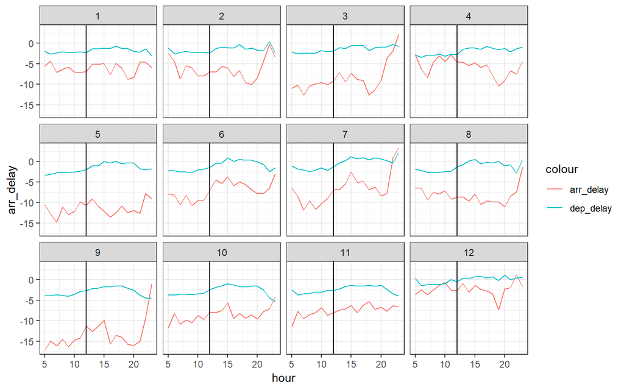

```r
# 우선, arr_delay와 dep_delay가 지나치게 높은건 제외시킨다.

zmad <- function(x) {
  (x - median(x, na.rm = TRUE)) / mad(x, na.rm = TRUE)
}

flights2 <- flights %>%
  mutate(
    zmad_arr_delay = zmad(arr_delay),
    zmad_dep_delay = zmad(dep_delay)
  ) %>%
  filter(abs(zmad_arr_delay) < 3.5, abs(zmad_dep_delay) < 3.5) %>% # 이상치 제거
  select(year:day, hour, carrier, flight, dest, dep_delay, arr_delay) %>%
  group_by(month, hour) %>%
  summarise(arr_delay = mean(arr_delay, na.rm = TRUE),
            dep_delay = mean(dep_delay, na.rm = TRUE))

ggplot(flights2, aes(hour)) +
  geom_line(aes(y = arr_delay, colour = "arr_delay")) +
  geom_line(aes(y = dep_delay, colour = "dep_delay")) +
  facet_wrap(~month) +
  geom_vline(xintercept = 12) +
  theme_bw()
```

오전시간이 대체로 기다리지 않아도 된다. 하루동안의 축적된 연쇄반응이거나 야간 비행의 어려움, 또는 야간에 도착하는 비행기가 비행 거리가 멀 수도 있다.

요일로도 해보자.

```r
library(lubridate)
```

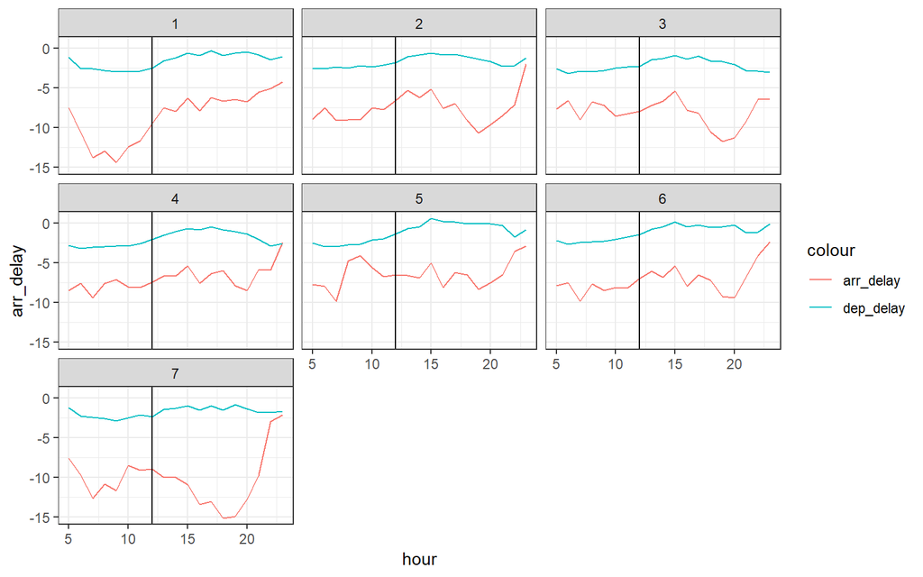

```r
flights3 <- flights %>%
  mutate(
    zmad_arr_delay = zmad(arr_delay),
    zmad_dep_delay = zmad(dep_delay),
    date =  make_datetime(year, month, day, hour),
    wday = wday(date)
  ) %>%
  filter(abs(zmad_arr_delay) < 3.5, abs(zmad_dep_delay) < 3.5) %>% # 이상치 제거
  select(year:day,wday, hour, carrier, flight, dest, dep_delay, arr_delay) %>%
  group_by(wday, hour) %>%
  summarise(arr_delay = mean(arr_delay, na.rm = TRUE),
            dep_delay = mean(dep_delay, na.rm = TRUE))

ggplot(flights3, aes(hour)) +
  geom_line(aes(y = arr_delay, colour = "arr_delay")) +
  geom_line(aes(y = dep_delay, colour = "dep_delay")) +
  facet_wrap(~wday) +
  geom_vline(xintercept = 12) +
  theme_bw()
```

3. For each destination, compute the total minutes of delay. For each flight, compute the proportion of the total delay for its destination.

```r
flights %>%
  group_by(dest, flight) %>%
  summarise(tot_arr_delay = sum(arr_delay, na.rm = TRUE),
         tot_dep_delay = sum(dep_delay, na.rm = TRUE)) %>%
  group_by(dest) %>%
  mutate(avg_arr_delay = tot_arr_delay / sum(tot_arr_delay),
         avg_dep_delay = tot_dep_delay / sum(tot_dep_delay)) %>%
  select(dest, flight, ends_with("arr_delay"), ends_with("dep_delay"))
```

```
## # A tibble: 11,467 x 6
## # Groups:   dest [105]
##    dest  flight tot_arr_delay avg_arr_delay tot_dep_delay avg_dep_delay
##    <chr>  <int>         <dbl>         <dbl>         <dbl>         <dbl>
##  1 ABQ       65           605       0.544            1239      0.355
##  2 ABQ     1505           508       0.456            2251      0.645
##  3 ACK     1191           652       0.509             614      0.359
##  4 ACK     1195            20       0.0156             33      0.0193
##  5 ACK     1291           234       0.183             250      0.146
##  6 ACK     1491           375       0.293             814      0.476
##  7 ALB     3256           -12      -0.00199             6      0.000606
##  8 ALB     3260           111       0.0184            119      0.0120
##  9 ALB     3264           -47      -0.00781             1      0.000101
## 10 ALB     3811           570       0.0947            570      0.0576
## # ... with 11,457 more rows
```

*중요* 4. Delays are typically temporally correlated: even once the problem that caused the initial delay has been resolved, later flights are delayed to allow earlier flights to leave. Using lag() explores how the delay of a flight is related to the delay of the immediately preceding flight.

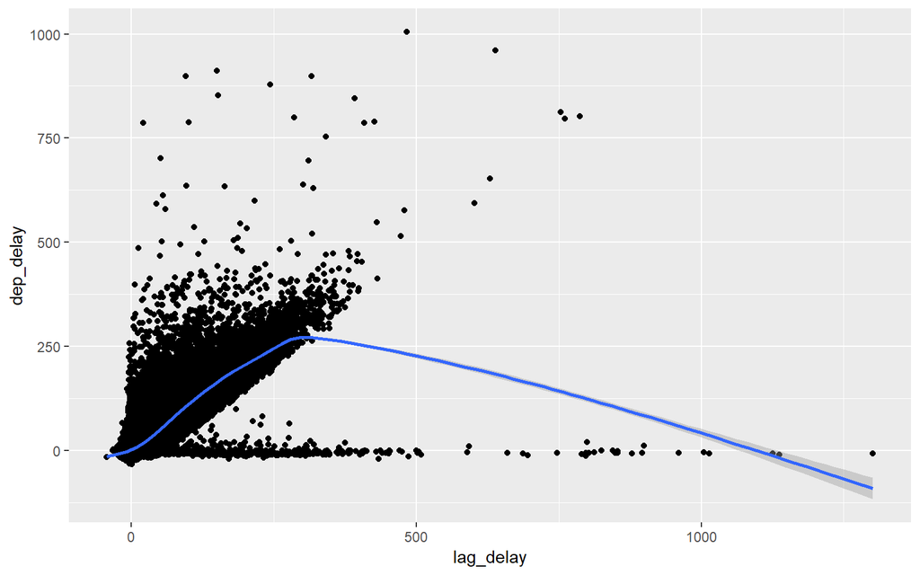

```r
flights %>%
  group_by(year, month, day, hour) %>%
  filter(!is.na(dep_delay)) %>%
  mutate(lag_delay = lag(dep_delay)) %>%
  filter(!is.na(lag_delay)) %>%
  ggplot(aes(lag_delay, dep_delay)) +
  geom_point() +
  geom_smooth()
```

이 부분은 시계열 배우고 다시 풀자.

```r
flights %>%
  mutate(new_sched_dep_time = lubridate::make_datetime(year, month, day, hour, minute)) %>%
  group_by(origin) %>%
  arrange(new_sched_dep_time) %>%
  mutate(prev_flight_dep_delay = lag(dep_delay)) %>%
  lm(dep_delay ~ prev_flight_dep_delay,.) %>% summary()
```

```
##
## Call:
## lm(formula = dep_delay ~ prev_flight_dep_delay, data = .)
##
## Residuals:
##     Min      1Q  Median      3Q     Max
## -356.11  -14.51  -10.51   -0.57 1284.55
##
## Coefficients:
##                       Estimate Std. Error t value Pr(>|t|)
## (Intercept)           9.091809   0.069862   130.1   <2e-16 ***
## prev_flight_dep_delay 0.262887   0.001728   152.1   <2e-16 ***
## ---
## Signif. codes:  0 '***' 0.001 '**' 0.01 '*' 0.05 '.' 0.1 ' ' 1
##
## Residual standard error: 37.94 on 322391 degrees of freedom
##   (14383 observations deleted due to missingness)
## Multiple R-squared:  0.06696,    Adjusted R-squared:  0.06695
## F-statistic: 2.314e+04 on 1 and 322391 DF,  p-value: < 2.2e-16
```

5. Look at each destination. Can you find flights that are suspiciously fast? (That is, flights that represent a potential data entry error.) Compute the air time of a flight relative to the shortest flight to that destination. Which flights were most delayed in the air?

```r
zmad <- function(x) (x - median(x, na.rm = TRUE)) / mad(x, na.rm = TRUE)
flights %>%
  group_by(dest) %>%
  mutate(zmad_air = abs(zmad(air_time))) %>%
  filter(zmad_air > 3.5) %>%
  select(dest, air_time, zmad_air) %>%
  arrange(air_time, desc(zmad_air))
```

```
## # A tibble: 1,900 x 3
## # Groups:   dest [89]
##    dest  air_time zmad_air
##    <chr>    <dbl>    <dbl>
##  1 BOS         21     3.82
##  2 BTV         34     4.05
##  3 RIC         35     4.05
##  4 BTV         35     3.71
##  5 BDL         36     3.71
##  6 BUF         38     3.82
##  7 BDL         39     4.72
##  8 BDL         41     5.40
##  9 ALB         42     3.71
## 10 ALB         43     4.05
## # ... with 1,890 more rows
```

6. Find all destinations that are flown by at least two carriers. Use that information to rank the carriers.

```r
flights %>%
  group_by(dest) %>%
  summarise(count_carriers = n_distinct(carrier)) %>%
  filter(count_carriers >=2 ) %>%
  mutate(rank_carrier = min_rank(desc(count_carriers))) %>%
  arrange(desc(count_carriers))
```

```
## # A tibble: 76 x 3
##    dest  count_carriers rank_carrier
##    <chr>          <int>        <int>
##  1 ATL                7            1
##  2 BOS                7            1
##  3 CLT                7            1
##  4 ORD                7            1
##  5 TPA                7            1
##  6 AUS                6            6
##  7 DCA                6            6
##  8 DTW                6            6
##  9 IAD                6            6
## 10 MSP                6            6
## # ... with 66 more rows
```

# 3 Summary

- `select()`와 `strats_with()`, `ends_with()`, `contains()`, `matches("(.)\\1")`, and `num_range("x", 1:3)` 함께 사용. `everything()`, `one_of()`은 참조변수와 활용
- 나머지연산자와 offset, 누적함수, 순위 연산자 적절히 사용
- 작은 수의 관측치를 제거하면 작은 그룹의 변동을 제거하여 분포를 보는데에 도움이 된다.
- 논리 subsetting과 mean, median함께 사용하면 도움